# What affects the outcome status of a Prosper Loan?

## by (Dominic Nyoni)

## Investigation Overview

This investigation seeks to explore the factors that affect the outcome status of a Prosper Loan. The main factors i focused on were Prosper Score and Borrower/Interest rate.Key findings indicate that Prosper Score and BorrowerRate/interest rate have the most effect on the loan outcome status.In particular,borrowers who have high prosper scores and interest rates below 20% tend to complete payment of their loans as opposed to borrowers with low to average prosper scores and interest rates over 20%.

## Dataset Overview

The data consists of information regarding 113,937 loans from ProsperLoans, including LoanStatus, BorrowerRate, and ProsperScore. Prosperscore is a custom risk score built using historical Prosper data. The score ranges from 1-10, with 10 being the best, or lowest risk score.

## What is the status of loans among our borrowers?

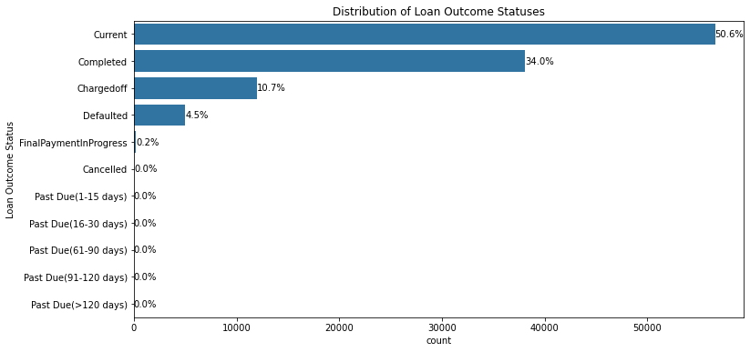

## Why interest rate really matters

Our chart clearly show that borrowers who completed their loans have a median interest rate that is around 7 points lower than borrowers who failed to do so.Moreover,a comparison of distribution of loans show that the group that completed their payment is more frequent at 10% and 15% interest rates while the group that failed is more congregated at about 31%. Interest rates also decrease as we go from low prosper score to high ones.In fact the gap between median interest rate of low prosper score and that of high prosper scores is almost 10 points!It is a strong indication that interest rates really do affect the outcome status of loans.

```
(0.798199045350523, 39.598215498111486)
```

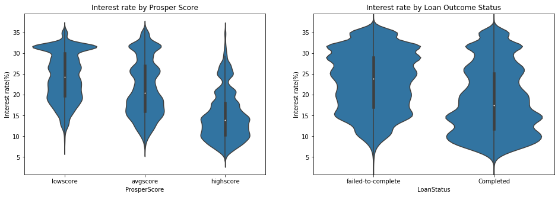

## High Prosper scores dominate the list of borrowers who completed their payments

The distribution of prosper scores among borrowers who completed their loan payments show that high prosper scores(7-10) are a clear majority while the low scores(below 5) are the least frequent.

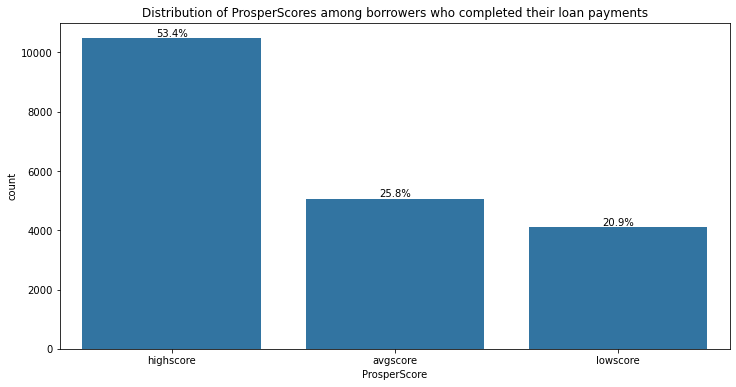